# StarbucksWorkspace

Further exploration and analysis of this dataframe could unveil patterns, preferences, and trends that could inform targeted marketing strategies to enhance customer engagement and satisfaction.

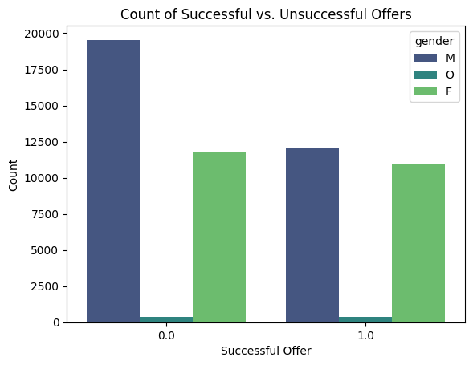

```python
sns.countplot(x='successful offer', data=overall_df, palette='viridis',hue="gender")
plt.title('Count of Successful vs. Unsuccessful Offers')
plt.xlabel('Successful Offer')
plt.ylabel('Count')
plt.show()
```

```python
def change_offer_id(df):
    unique_offer_ids = df['offer_id'].unique()
    offer_id_mapping = {offer_id: f'Offer {i+1}' for i, offer_id in enumerate(unique_offer_ids)}

    df['offer_id'] = df['offer_id'].map(offer_id_mapping)

    return df

# Apply the function to change offer IDs in overall_df
overall_df = change_offer_id(overall_df)
```

```python
overall_df.head()
```

|  | customer_id | offer_id | successful offer | reward | difficulty | duration | web | email | mobile | social | ... | offer_type_discount | offer_type_informational | gender | age | became_member_on | income | gender-F | gender-M | gender-O | number_of_days |
| --- | --- | --- | --- | --- | --- | --- | --- | --- | --- | --- | --- | --- | --- | --- | --- | --- | --- | --- | --- | --- | --- |
| 0 | 0009655768c64bdeb2e877511632db8f | Offer 1 | 0.0 | 2 | 10 | 7 | 1 | 1 | 1 | 0 | ... | 1 | 0 | M | 33.0 | 2017-04-21 | 72000.0 | False | True | False | 2423.0 |
| 1 | 0009655768c64bdeb2e877511632db8f | Offer 2 | 0.0 | 0 | 0 | 4 | 1 | 1 | 1 | 0 | ... | 0 | 1 | M | 33.0 | 2017-04-21 | 72000.0 | False | True | False | 2423.0 |
| 2 | 0009655768c64bdeb2e877511632db8f | Offer 3 | 0.0 | 0 | 0 | 3 | 0 | 1 | 1 | 1 | ... | 0 | 1 | M | 33.0 | 2017-04-21 | 72000.0 | False | True | False | 2423.0 |
| 3 | 0009655768c64bdeb2e877511632db8f | Offer 4 | 1.0 | 5 | 5 | 5 | 1 | 1 | 1 | 1 | ... | 0 | 0 | M | 33.0 | 2017-04-21 | 72000.0 | False | True | False | 2423.0 |
| 4 | 0009655768c64bdeb2e877511632db8f | Offer 5 | 1.0 | 2 | 10 | 10 | 1 | 1 | 1 | 1 | ... | 1 | 0 | M | 33.0 | 2017-04-21 | 72000.0 | False | True | False | 2423.0 |

5 rows × 21 columns

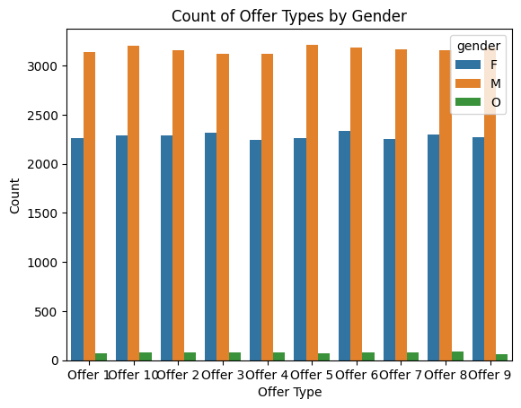

```python
# Group the data by offer type and gender and get the count
offer_type_gender_count = overall_df.groupby(['offer_id', 'gender']).size().reset_index(name='count')

# Create a bar plot
sns.barplot(x='offer_id', y='count', hue='gender', data=offer_type_gender_count)
plt.title('Count of Offer Types by Gender')
plt.xlabel('Offer Type')
plt.ylabel('Count')
plt.show()
```

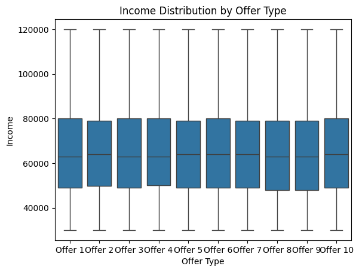

```python
sns.boxplot(data=overall_df, x='offer_id', y='income')
plt.title('Income Distribution by Offer Type')
plt.xlabel('Offer Type')
plt.ylabel('Income')
plt.show()
```

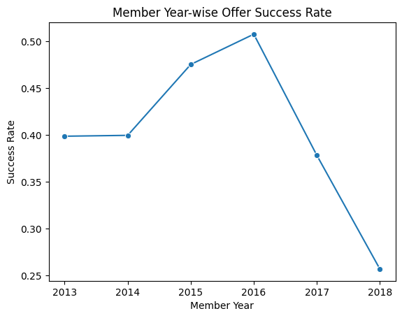

```python
success_rate_by_year = overall_df.groupby('member_year')['successful offer'].mean().reset_index()

sns.lineplot(data=success_rate_by_year, x='member_year', y='successful offer', marker='o')
plt.title('Member Year-wise Offer Success Rate')
plt.xlabel('Member Year')
plt.ylabel('Success Rate')
plt.show()
```

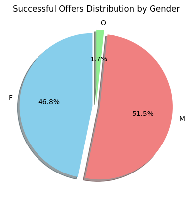

```python
# Calculate the count of successful offers by gender
success_by_gender = overall_df.groupby('gender')['successful offer'].sum()

plt.pie(success_by_gender,shadow=True, labels=success_by_gender.index, explode = (0.05,0.05,0.05),autopct='%1.1f%%', startangle=90, colors=['skyblue', 'lightcoral', 'lightgreen'])
plt.title('Successful Offers Distribution by Gender')
plt.show()
```

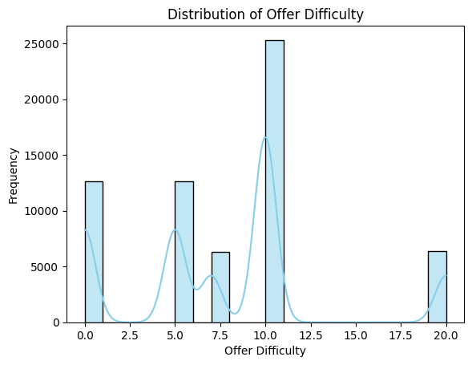

```python
sns.histplot(data=overall_df, x='difficulty', bins=20, kde=True, color='skyblue')
plt.title('Distribution of Offer Difficulty')
plt.xlabel('Offer Difficulty')
plt.ylabel('Frequency')
plt.show()
```

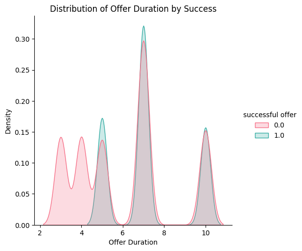

```python
sns.displot(data=overall_df, x='duration', hue='successful offer', kind='kde', fill=True, palette='husl')
plt.title('Distribution of Offer Duration by Success')
plt.xlabel('Offer Duration')
plt.ylabel('Density')
plt.show()
```

## Modeling

```python
overall_df.head()
```

|  | customer_id | offer_id | successful offer | reward | difficulty | duration | web | email | mobile | social | ... | offer_type_discount | offer_type_informational | gender | age | became_member_on | income | gender-F | gender-M | gender-O | number_of_days |
| --- | --- | --- | --- | --- | --- | --- | --- | --- | --- | --- | --- | --- | --- | --- | --- | --- | --- | --- | --- | --- | --- |
| 0 | 0009655768c64bdeb2e877511632db8f | Offer 1 | 0.0 | 2 | 10 | 7 | 1 | 1 | 1 | 0 | ... | 1 | 0 | M | 33.0 | 2017-04-21 | 72000.0 | False | True | False | 2423.0 |
| 1 | 0009655768c64bdeb2e877511632db8f | Offer 2 | 0.0 | 0 | 0 | 4 | 1 | 1 | 1 | 0 | ... | 0 | 1 | M | 33.0 | 2017-04-21 | 72000.0 | False | True | False | 2423.0 |
| 2 | 0009655768c64bdeb2e877511632db8f | Offer 3 | 0.0 | 0 | 0 | 3 | 0 | 1 | 1 | 1 | ... | 0 | 1 | M | 33.0 | 2017-04-21 | 72000.0 | False | True | False | 2423.0 |
| 3 | 0009655768c64bdeb2e877511632db8f | Offer 4 | 1.0 | 5 | 5 | 5 | 1 | 1 | 1 | 1 | ... | 0 | 0 | M | 33.0 | 2017-04-21 | 72000.0 | False | True | False | 2423.0 |
| 4 | 0009655768c64bdeb2e877511632db8f | Offer 5 | 1.0 | 2 | 10 | 10 | 1 | 1 | 1 | 1 | ... | 1 | 0 | M | 33.0 | 2017-04-21 | 72000.0 | False | True | False | 2423.0 |

5 rows × 21 columns

```python
df = pd.get_dummies(overall_df, columns=['gender'], prefix='gender')
df.drop(columns=['gender-F','gender-M','gender-O','became_member_on','customer_id'], inplace=True)
df[['gender_F', 'gender_M', 'gender_O']] = df[['gender_F', 'gender_M', 'gender_O']].astype(int)
```

```python
df.head()
```

[output not shown]

```python
def encode_offer_id(X):

    '''
    Fuction to encode offer id into dummy columns.

    Input - X dataframe with offer_id column present

    Output - X dataframe with encoded columns for offer id

    '''

    dummies = pd.get_dummies(X['offer_id'],dtype=int)

    new = pd.concat([X.drop('offer_id',axis=1), dummies],axis=1)


    return new
```

```python
df = encode_offer_id(df)
```

```python
for col in ['age','income']:
    df[col] = df[col].fillna(df[col].median())
```

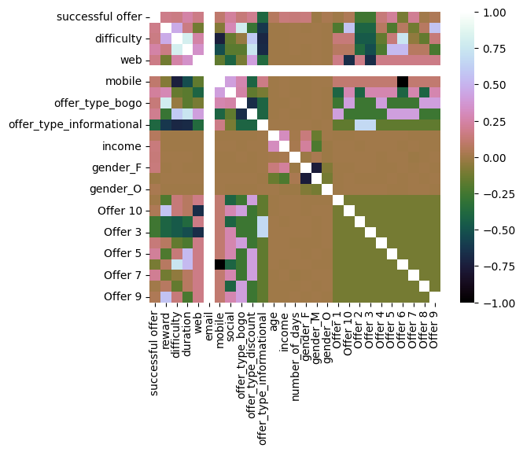

```python
sns.heatmap(df.corr(),square=True, cmap='cubehelix');
```

```python
# Features and target variable
features = df[['reward', 'difficulty', 'duration', 'web', 'email', 'mobile', 'social',
                        'offer_type_bogo', 'offer_type_discount', 'offer_type_informational',
                        'age', 'income', 'number_of_days', 'gender_F', 'gender_M', 'gender_O',
                        'Offer 1', 'Offer 10', 'Offer 2', 'Offer 3', 'Offer 4', 'Offer 5',
                        'Offer 6', 'Offer 7', 'Offer 8', 'Offer 9']]
target = df['successful offer']
```

```python
from sklearn.model_selection import train_test_split
from sklearn.preprocessing import StandardScaler
from sklearn.linear_model import LogisticRegression
from sklearn.metrics import accuracy_score, classification_report, confusion_matrix

# Split the data into training and testing sets
X_train, X_test, y_train, y_test = train_test_split(features, target, test_size=0.2, random_state=42)

# Standardize the features
scaler = StandardScaler()
X_train_scaled = scaler.fit_transform(X_train)
X_test_scaled = scaler.transform(X_test)

# Create and train the Logistic Regression model
model = LogisticRegression(random_state=42)
model.fit(X_train_scaled, y_train)

# Make predictions on the test set
y_pred = model.predict(X_test_scaled)

# Evaluate the model
accuracy = accuracy_score(y_test, y_pred)
conf_matrix = confusion_matrix(y_test, y_pred)
classification_rep = classification_report(y_test, y_pred)

# Display the results
print("Accuracy:", accuracy)
print("\nConfusion Matrix:\n", conf_matrix)
print("\nClassification Report:\n", classification_rep)
```

```
Accuracy: 0.7569916258492653

Confusion Matrix:
 [[6183 1568]
 [1508 3399]]

Classification Report:
               precision    recall  f1-score   support

         0.0       0.80      0.80      0.80      7751
         1.0       0.68      0.69      0.69      4907

    accuracy                           0.76     12658
   macro avg       0.74      0.75      0.74     12658
weighted avg       0.76      0.76      0.76     12658
```

```python
#Trying KNN, did not give out good results, please ignore.
```

```python
from sklearn.neighbors import KNeighborsClassifier

# Create a KNN Classifier
knn_classifier = KNeighborsClassifier()

# Train the model
knn_classifier.fit(X_train, y_train)

# Make predictions
knn_predictions = knn_classifier.predict(X_test)
```

```
Accuracy: 0.6595828724917049
Classification Report:
              precision    recall  f1-score   support

         0.0       0.73      0.71      0.72      7751
         1.0       0.56      0.57      0.57      4907

    accuracy                           0.66     12658
   macro avg       0.64      0.64      0.64     12658
weighted avg       0.66      0.66      0.66     12658
```

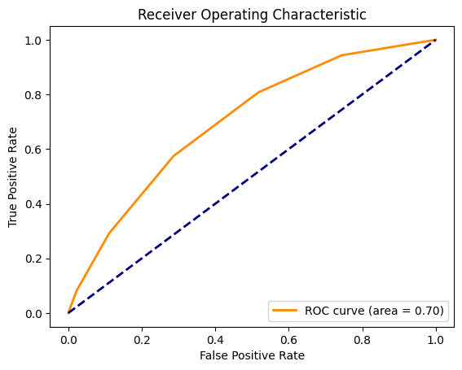

```python
accuracy = accuracy_score(y_test, knn_predictions)
print(f'Accuracy: {accuracy}')
from sklearn.metrics import classification_report

class_report = classification_report(y_test, knn_predictions)
print('Classification Report:')
print(class_report)
from sklearn.metrics import roc_curve, auc
import matplotlib.pyplot as plt

# Compute ROC curve and AUC
fpr, tpr, _ = roc_curve(y_test, knn_classifier.predict_proba(X_test)[:, 1])
roc_auc = auc(fpr, tpr)

# Plot ROC curve
plt.figure()
plt.plot(fpr, tpr, color='darkorange', lw=2, label='ROC curve (area = {:.2f})'.format(roc_auc))
plt.plot([0, 1], [0, 1], color='navy', lw=2, linestyle='--')
plt.xlabel('False Positive Rate')
plt.ylabel('True Positive Rate')
plt.title('Receiver Operating Characteristic')
plt.legend(loc='lower right')
plt.show()
```

### Random Forest Classification

```python
df.head()
```

|  | successful offer | reward | difficulty | duration | web | email | mobile | social | offer_type_bogo | offer_type_discount | ... | Offer 1 | Offer 10 | Offer 2 | Offer 3 | Offer 4 | Offer 5 | Offer 6 | Offer 7 | Offer 8 | Offer 9 |
| --- | --- | --- | --- | --- | --- | --- | --- | --- | --- | --- | --- | --- | --- | --- | --- | --- | --- | --- | --- | --- | --- |
| 0 | 0.0 | 2 | 10 | 7 | 1 | 1 | 1 | 0 | 0 | 1 | ... | 1 | 0 | 0 | 0 | 0 | 0 | 0 | 0 | 0 | 0 |
| 1 | 0.0 | 0 | 0 | 4 | 1 | 1 | 1 | 0 | 0 | 0 | ... | 0 | 0 | 1 | 0 | 0 | 0 | 0 | 0 | 0 | 0 |
| 2 | 0.0 | 0 | 0 | 3 | 0 | 1 | 1 | 1 | 0 | 0 | ... | 0 | 0 | 0 | 1 | 0 | 0 | 0 | 0 | 0 | 0 |
| 3 | 1.0 | 5 | 5 | 5 | 1 | 1 | 1 | 1 | 1 | 0 | ... | 0 | 0 | 0 | 0 | 1 | 0 | 0 | 0 | 0 | 0 |
| 4 | 1.0 | 2 | 10 | 10 | 1 | 1 | 1 | 1 | 0 | 1 | ... | 0 | 0 | 0 | 0 | 0 | 1 | 0 | 0 | 0 | 0 |

5 rows × 27 columns

```python
import pandas as pd
from sklearn.model_selection import train_test_split
from sklearn.ensemble import RandomForestClassifier
from sklearn.model_selection import GridSearchCV
from sklearn.pipeline import Pipeline
from sklearn.preprocessing import StandardScaler
from sklearn.compose import ColumnTransformer
```

```python
# Assume 'X' contains your features and 'y' contains your target variable 'successful offer'
X = df.drop('successful offer', axis=1)
y = df['successful offer']

# Split the data into training and testing sets
X_train, X_test, y_train, y_test = train_test_split(X, y, test_size=0.2, random_state=42)

# Define a ColumnTransformer for preprocessing numerical and categorical features
numeric_features = ['reward', 'difficulty', 'duration', 'age', 'income', 'number_of_days']
categorical_features = ['web', 'email', 'mobile', 'social', 'offer_type_bogo', 'offer_type_discount', 'offer_type_informational', 'gender_F', 'gender_M', 'gender_O', 'Offer 1', 'Offer 10', 'Offer 2', 'Offer 3', 'Offer 4', 'Offer 5', 'Offer 6', 'Offer 7', 'Offer 8', 'Offer 9']

preprocessor = ColumnTransformer(
    transformers=[
        ('num', StandardScaler(), numeric_features),
        ('cat', 'passthrough', categorical_features)
    ])

# Create a pipeline with preprocessing and Random Forest classifier
pipeline = Pipeline([
    ('preprocessor', preprocessor),
    ('classifier', RandomForestClassifier())
])
```

```python
# Define hyperparameters for Grid Search
param_grid = {
    'classifier__n_estimators': [50, 100],
    'classifier__max_depth': [None, 10, 20],
    'classifier__min_samples_split': [2, 5, 10]
}
```

```python
# Create Grid Search
grid_search = GridSearchCV(pipeline, param_grid, cv=5, scoring='accuracy', n_jobs=-1)

# Fit the model
grid_search.fit(X_train, y_train)
```

```
GridSearchCV(cv=5,
             estimator=Pipeline(steps=[('preprocessor',
                                        ColumnTransformer(transformers=[('num',
                                                                         StandardScaler(),
                                                                         ['reward',
                                                                          'difficulty',
                                                                          'duration',
                                                                          'age',
                                                                          'income',
                                                                          'number_of_days']),
                                                                        ('cat',
                                                                         'passthrough',
                                                                         ['web',
                                                                          'email',
                                                                          'mobile',
                                                                          'social',
                                                                          'offer_type_bogo',
                                                                          'offer_type_discount',
                                                                          'offer_type_informational',
                                                                          'gender_F',
                                                                          'gender_M',
                                                                          'gender_O',
                                                                          'Offer '
                                                                          '1',
                                                                          'Offer '
                                                                          '10',
                                                                          'Offer '
                                                                          '2',
                                                                          'Offer '
                                                                          '3',
                                                                          'Offer '
                                                                          '4',
                                                                          'Offer '
                                                                          '5',
                                                                          'Offer '
                                                                          '6',
                                                                          'Offer '
                                                                          '7',
                                                                          'Offer '
                                                                          '8',
                                                                          'Offer '
                                                                          '9'])])),
                                       ('classifier',
                                        RandomForestClassifier())]),
             n_jobs=-1,
             param_grid={'classifier__max_depth': [None, 10, 20],
                         'classifier__min_samples_split': [2, 5, 10],
                         'classifier__n_estimators': [50, 100]},
             scoring='accuracy')
```

```python
# Print the best parameters and the corresponding accuracy
print("Best Parameters: ", grid_search.best_params_)
print("Best Accuracy: ", grid_search.best_score_)

# Evaluate the model on the test set
test_accuracy = grid_search.score(X_test, y_test)
print("Test Accuracy: ", test_accuracy)
```

```
Best Parameters:  {'classifier__max_depth': 10, 'classifier__min_samples_split': 10, 'classifier__n_estimators': 100}
Best Accuracy:  0.780130357495556
Test Accuracy:  0.7794280297045347
```

The evaluation metrics obtained for three different models — Random Forest with Grid Search, K-Nearest Neighbors (KNN), and Logistic Regression — several observations can be made.

#### Random Forest with Grid Search

- **Accuracy:** Achieved an accuracy of approximately 78% on the test set, with the best parameters found by Grid Search being max_depth=10, min_samples_split=10, and n_estimators=100.
- **Performance:** Significantly better accuracy compared to KNN and slightly higher than Logistic Regression.
- **Reasoning:** The grid search approach systematically explored a range of hyperparameters, optimizing the Random Forest model's depth, number of estimators, and minimum samples for splitting, leading to improved performance.

#### K-Nearest Neighbors (KNN)

- **Accuracy:** Achieved an accuracy of around 66% on the test set, with moderate precision and recall for both classes.
- **Performance:** Lower accuracy compared to Random Forest and Logistic Regression.
- **Observation:** KNN might not have captured the underlying patterns in the data as effectively as the other models due to its reliance on proximity-based calculations.

#### Logistic Regression

- **Accuracy:** Achieved an accuracy of approximately 76% on the test set, with a decent precision-recall balance for both classes.
- **Performance:** Falls between Random Forest and KNN in terms of accuracy.
- **Insight:** Logistic Regression assumes a linear relationship between features and the target, which might limit its ability to capture complex patterns compared to Random Forest.

### Conclusion

- **Grid Search Impact:** Grid Search for Random Forest allowed exhaustive parameter tuning, resulting in a model configuration that best fitted the data, evident from its higher accuracy compared to the other two models.
- **Model Suitability:** Random Forest, with the tuned hyperparameters, emerged as the best-performing model for this specific dataset, showcasing its adaptability to capture complex relationships between features and the target variable.

Each model's performance could vary depending on the dataset's characteristics, and in this case, Random Forest optimized via Grid Search stood out as the most effective approach for this classification task.